# Red Wine Quality by Eric Ambriza

# Introduction

##### The dataset contains 1,599 red wines with 11 variables on the chemical properties of the wine. which can be described as:

##### 1 - fixed acidity (tartaric acid - g / dm^3)

##### 2 - volatile acidity (acetic acid - g / dm^3)

##### 3 - citric acid (g / dm^3)

##### 4 - residual sugar (g / dm^3)

##### 5 - chlorides (sodium chloride - g / dm^3

##### 6 - free sulfur dioxide (mg / dm^3)

##### 7 - total sulfur dioxide (mg / dm^3)

##### 8 - density (g / cm^3)

##### 9 - pH

##### 10 - sulphates (potassium sulphate - g / dm3)

##### 11 - alcohol (% by volume)

##### Output variable (based on sensory data):

##### 12 - quality (score between 0 and 10)

##### Only quality is a categorical variable where the score is between 0 and 10. Three more categorical variables will be added to help on the anlysis:

##### - pH.levels : “Low”, “Medium”, “Mod_high”,“High”

##### - sugar.levels: “Low and High”

##### - alcohol.levels: “Low and High”

##### Lets follow along, to start exploring the data set on the bellow section.

# Wrangling the data

#### Dimension of the data set (Rows X Columns)

```
## [1] 1599   13
```

#### Column description

```
## 'data.frame':    1599 obs. of  13 variables:
##  $ X                   : int  1 2 3 4 5 6 7 8 9 10 ...
##  $ fixed.acidity       : num  7.4 7.8 7.8 11.2 7.4 7.4 7.9 7.3 7.8 7.5 ...
##  $ volatile.acidity    : num  0.7 0.88 0.76 0.28 0.7 0.66 0.6 0.65 0.58 0.5 ...
##  $ citric.acid         : num  0 0 0.04 0.56 0 0 0.06 0 0.02 0.36 ...
##  $ residual.sugar      : num  1.9 2.6 2.3 1.9 1.9 1.8 1.6 1.2 2 6.1 ...
##  $ chlorides           : num  0.076 0.098 0.092 0.075 0.076 0.075 0.069 0.065 0.073 0.071 ...
##  $ free.sulfur.dioxide : num  11 25 15 17 11 13 15 15 9 17 ...
##  $ total.sulfur.dioxide: num  34 67 54 60 34 40 59 21 18 102 ...
##  $ density             : num  0.998 0.997 0.997 0.998 0.998 ...
##  $ pH                  : num  3.51 3.2 3.26 3.16 3.51 3.51 3.3 3.39 3.36 3.35 ...
##  $ sulphates           : num  0.56 0.68 0.65 0.58 0.56 0.56 0.46 0.47 0.57 0.8 ...
##  $ alcohol             : num  9.4 9.8 9.8 9.8 9.4 9.4 9.4 10 9.5 10.5 ...
##  $ quality             : int  5 5 5 6 5 5 5 7 7 5 ...
```

#### Summary

```
##        X          fixed.acidity   volatile.acidity  citric.acid
##  Min.   :   1.0   Min.   : 4.60   Min.   :0.1200   Min.   :0.000
##  1st Qu.: 400.5   1st Qu.: 7.10   1st Qu.:0.3900   1st Qu.:0.090
##  Median : 800.0   Median : 7.90   Median :0.5200   Median :0.260
##  Mean   : 800.0   Mean   : 8.32   Mean   :0.5278   Mean   :0.271
##  3rd Qu.:1199.5   3rd Qu.: 9.20   3rd Qu.:0.6400   3rd Qu.:0.420
##  Max.   :1599.0   Max.   :15.90   Max.   :1.5800   Max.   :1.000
##  residual.sugar     chlorides       free.sulfur.dioxide
##  Min.   : 0.900   Min.   :0.01200   Min.   : 1.00
##  1st Qu.: 1.900   1st Qu.:0.07000   1st Qu.: 7.00
##  Median : 2.200   Median :0.07900   Median :14.00
##  Mean   : 2.539   Mean   :0.08747   Mean   :15.87
##  3rd Qu.: 2.600   3rd Qu.:0.09000   3rd Qu.:21.00
##  Max.   :15.500   Max.   :0.61100   Max.   :72.00
##  total.sulfur.dioxide    density             pH          sulphates
##  Min.   :  6.00       Min.   :0.9901   Min.   :2.740   Min.   :0.3300
##  1st Qu.: 22.00       1st Qu.:0.9956   1st Qu.:3.210   1st Qu.:0.5500
##  Median : 38.00       Median :0.9968   Median :3.310   Median :0.6200
##  Mean   : 46.47       Mean   :0.9967   Mean   :3.311   Mean   :0.6581
##  3rd Qu.: 62.00       3rd Qu.:0.9978   3rd Qu.:3.400   3rd Qu.:0.7300
##  Max.   :289.00       Max.   :1.0037   Max.   :4.010   Max.   :2.0000
##     alcohol         quality
##  Min.   : 8.40   Min.   :3.000
##  1st Qu.: 9.50   1st Qu.:5.000
##  Median :10.20   Median :6.000
##  Mean   :10.42   Mean   :5.636
##  3rd Qu.:11.10   3rd Qu.:6.000
##  Max.   :14.90   Max.   :8.000
```

```
##         X fixed.acidity volatile.acidity citric.acid residual.sugar
## 1595 1595           6.2            0.600        0.08            2.0
## 1596 1596           5.9            0.550        0.10            2.2
## 1597 1597           6.3            0.510        0.13            2.3
## 1598 1598           5.9            0.645        0.12            2.0
## 1599 1599           6.0            0.310        0.47            3.6
##      chlorides free.sulfur.dioxide total.sulfur.dioxide density   pH
## 1595     0.090                  32                   44 0.99490 3.45
## 1596     0.062                  39                   51 0.99512 3.52
## 1597     0.076                  29                   40 0.99574 3.42
## 1598     0.075                  32                   44 0.99547 3.57
## 1599     0.067                  18                   42 0.99549 3.39
##      sulphates alcohol quality
## 1595      0.58    10.5       5
## 1596      0.76    11.2       6
## 1597      0.75    11.0       6
## 1598      0.71    10.2       5
## 1599      0.66    11.0       6
```

# 1. Univariate_Plots Section

## 1.1 - Quality

```
##
##   3   4   5   6   7   8
##  10  53 681 638 199  18
```

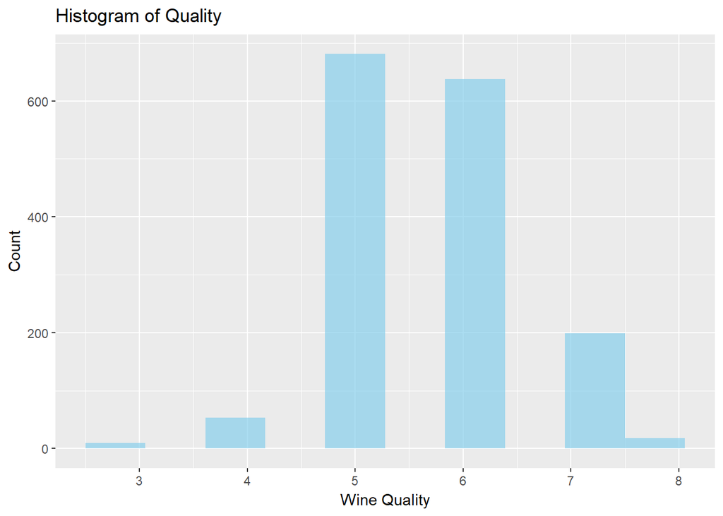

##### Quality can range form 3 up to 8, where most of the wines were rated as 5 and 6 letting the remain quality low and high with few counts. This behave can also persuade to rate them as low, medium and high for better understanding on bivariate and multivariate analysis.

## 1.2 - Alcohol

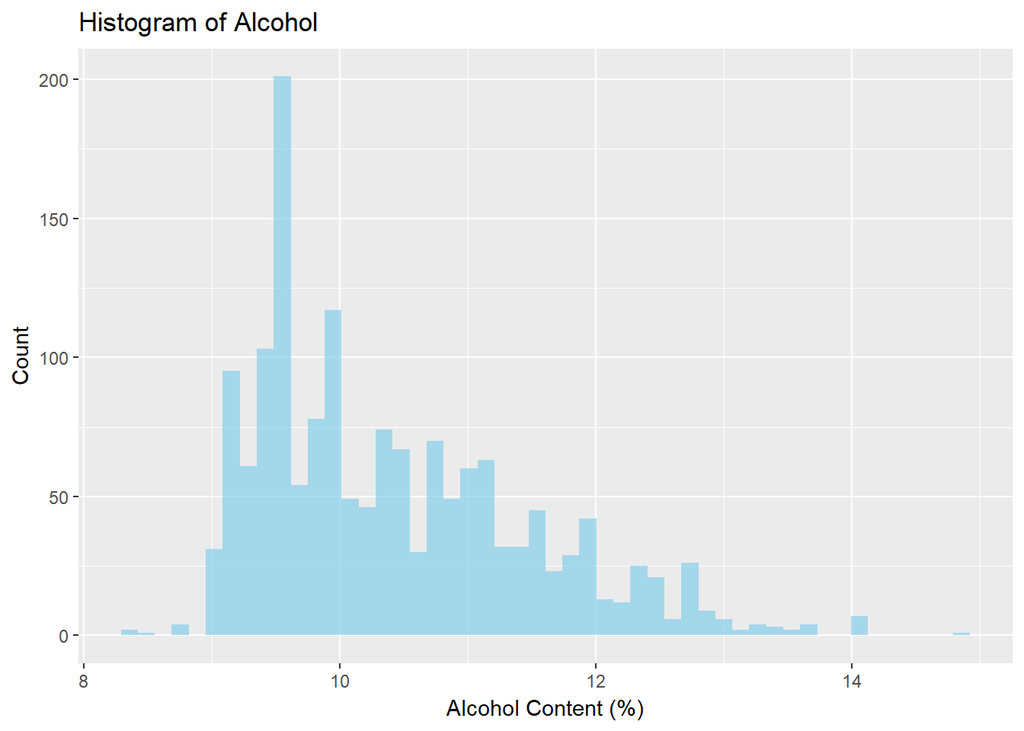

```
##    Min. 1st Qu.  Median    Mean 3rd Qu.    Max.
##    8.40    9.50   10.20   10.42   11.10   14.90
```

```
##
##              8.4              8.5              8.7              8.8
##                2                1                2                2
##                9             9.05              9.1              9.2
##               30                1               23               72
## 9.23333333333333             9.25              9.3              9.4
##                1                1               59              103
##              9.5             9.55 9.56666666666667              9.6
##              139                2                1               59
##              9.7              9.8              9.9             9.95
##               54               78               49                1
##               10 10.0333333333333             10.1             10.2
##               67                2               47               46
##             10.3             10.4             10.5            10.55
##               33               41               67                2
##             10.6             10.7            10.75             10.8
##               28               27                1               42
##             10.9               11 11.0666666666667             11.1
##               49               59                1               27
##             11.2             11.3             11.4             11.5
##               36               32               32               30
##             11.6             11.7             11.8             11.9
##               15               23               29               20
##            11.95               12             12.1             12.2
##                1               21               13               12
##             12.3             12.4             12.5             12.6
##               12               13               21                6
##             12.7             12.8             12.9               13
##                9               17                9                6
##             13.1             13.2             13.3             13.4
##                2                1                3                3
##             13.5 13.5666666666667             13.6               14
##                1                1                4                7
##             14.9
##                1
```

##### This can range from 8 up to 15% were can be noticed a right skwed distribuiton where the low levels of alcohol seems to be more frequent. From the all variables is the feature most correlated with quality (cor = 0.48). Decided to create a new variable setting 2 levels (low and high alcohol) for a much detailed vizualization among the varaibles.

## 1.3 - Sulphates

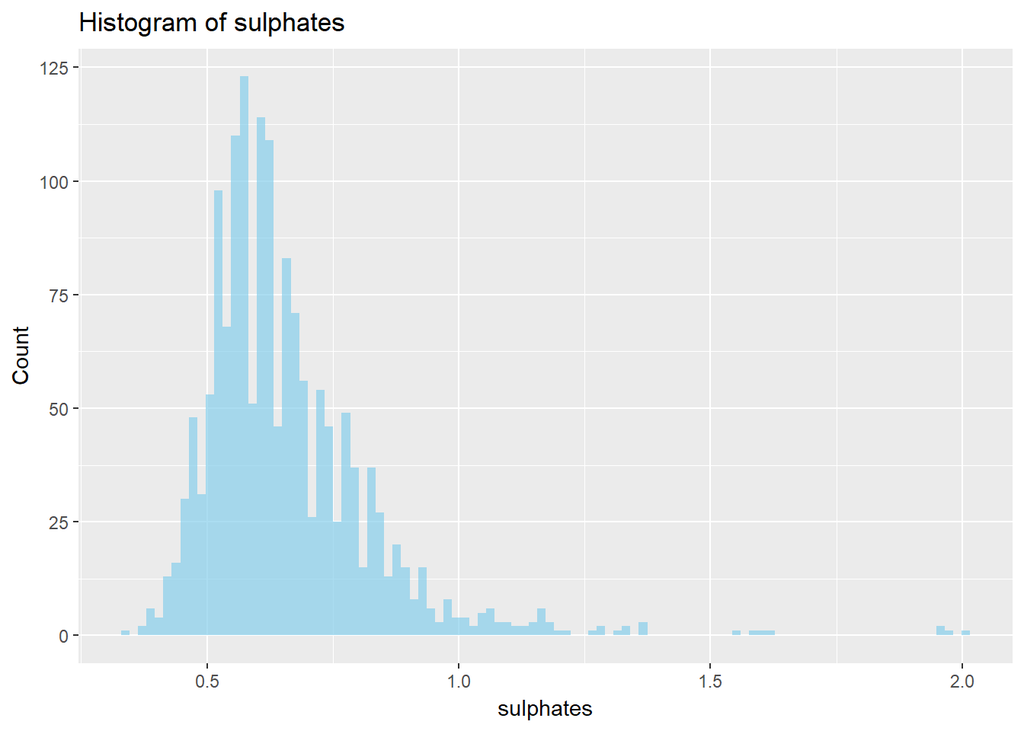

```
##    Min. 1st Qu.  Median    Mean 3rd Qu.    Max.
##  0.3300  0.5500  0.6200  0.6581  0.7300  2.0000
```

```
##
## 0.33 0.37 0.39  0.4 0.42 0.43 0.44 0.45 0.46 0.47 0.48 0.49  0.5 0.51 0.52
##    1    2    6    4    5    8   16   12   18   19   29   31   27   26   47
## 0.53 0.54 0.55 0.56 0.57 0.58 0.59  0.6 0.61 0.62 0.63 0.64 0.65 0.66 0.67
##   51   68   50   60   55   68   51   69   45   61   48   46   41   42   36
## 0.68 0.69  0.7 0.71 0.72 0.73 0.74 0.75 0.76 0.77 0.78 0.79  0.8 0.81 0.82
##   35   23   33   26   28   26   26   20   25   26   23   18   19   15   22
## 0.83 0.84 0.85 0.86 0.87 0.88 0.89  0.9 0.91 0.92 0.93 0.94 0.95 0.96 0.97
##   15   13   14   13   13    7    7    8    8    5   10    4    2    3    6
## 0.98 0.99    1 1.01 1.02 1.03 1.04 1.05 1.06 1.07 1.08 1.09  1.1 1.11 1.12
##    2    3    1    1    3    2    2    3    4    2    3    1    2    1    1
## 1.13 1.14 1.15 1.16 1.17 1.18  1.2 1.22 1.26 1.28 1.31 1.33 1.34 1.36 1.56
##    2    2    1    1    5    3    1    1    1    2    1    1    1    3    1
## 1.59 1.61 1.62 1.95 1.98    2
##    1    1    1    2    1    1
```

## 1.4 - PH

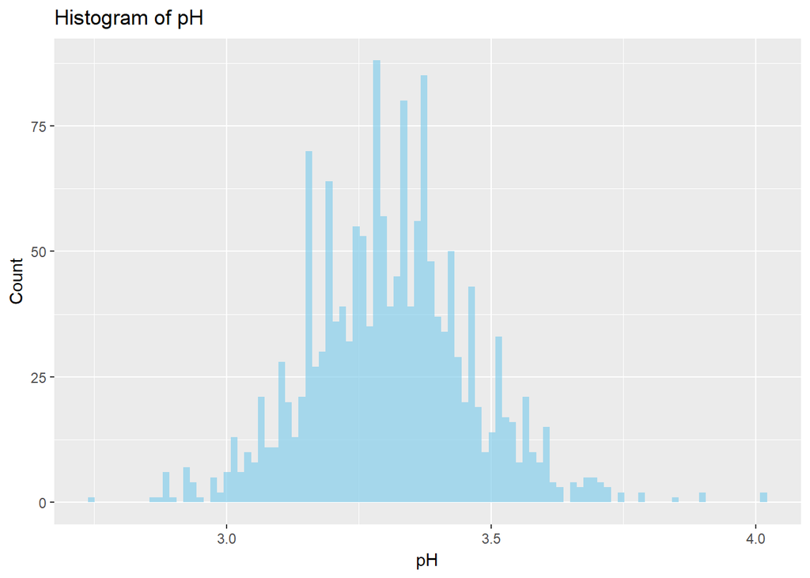

```
##    Min. 1st Qu.  Median    Mean 3rd Qu.    Max.
##   2.740   3.210   3.310   3.311   3.400   4.010
```

```
##
## 2.74 2.86 2.87 2.88 2.89  2.9 2.92 2.93 2.94 2.95 2.98 2.99    3 3.01 3.02
##    1    1    1    2    4    1    4    3    4    1    5    2    6    5    8
## 3.03 3.04 3.05 3.06 3.07 3.08 3.09  3.1 3.11 3.12 3.13 3.14 3.15 3.16 3.17
##    6   10    8   10   11   11   11   19    9   20   13   21   34   36   27
## 3.18 3.19  3.2 3.21 3.22 3.23 3.24 3.25 3.26 3.27 3.28 3.29  3.3 3.31 3.32
##   30   25   39   36   39   32   29   26   53   35   42   46   57   39   45
## 3.33 3.34 3.35 3.36 3.37 3.38 3.39  3.4 3.41 3.42 3.43 3.44 3.45 3.46 3.47
##   37   43   39   56   37   48   48   37   34   33   17   29   20   22   21
## 3.48 3.49  3.5 3.51 3.52 3.53 3.54 3.55 3.56 3.57 3.58 3.59  3.6 3.61 3.62
##   19   10   14   15   18   17   16    8   11   10   10    8    7    8    4
## 3.63 3.66 3.67 3.68 3.69  3.7 3.71 3.72 3.74 3.75 3.78 3.85  3.9 4.01
##    3    4    3    5    4    1    4    3    1    1    2    1    2    2
```

##### Mean and Median almost the same, confirming the normal distribuition with a few spikes shaped on the above histogram.

## 1.5 - Density

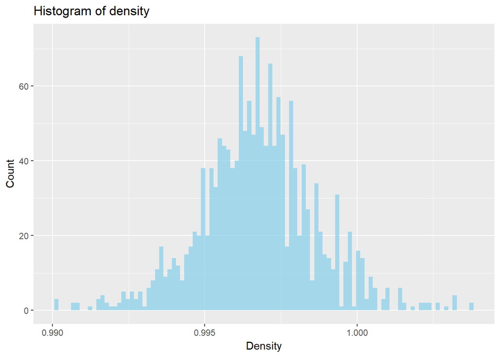

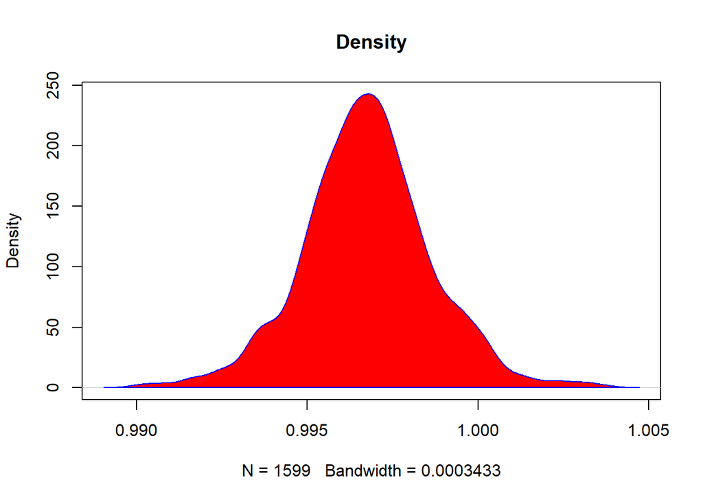

##### Both pH and density are normaly distribuited, density has 2 peaks on both sides of the main peak. Would be nice to combine these two variables along side with residual sugar to understand if the common values on these plots can be related with a certian type of quality.

## 1.6 - Total Sulfur Dioxide

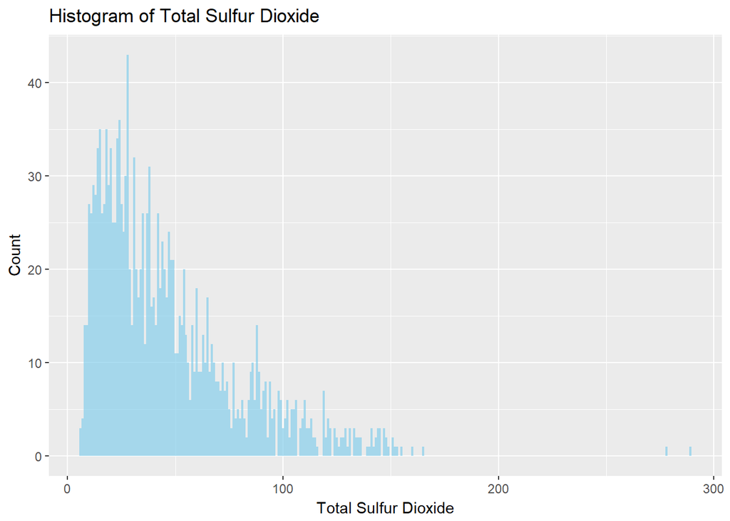

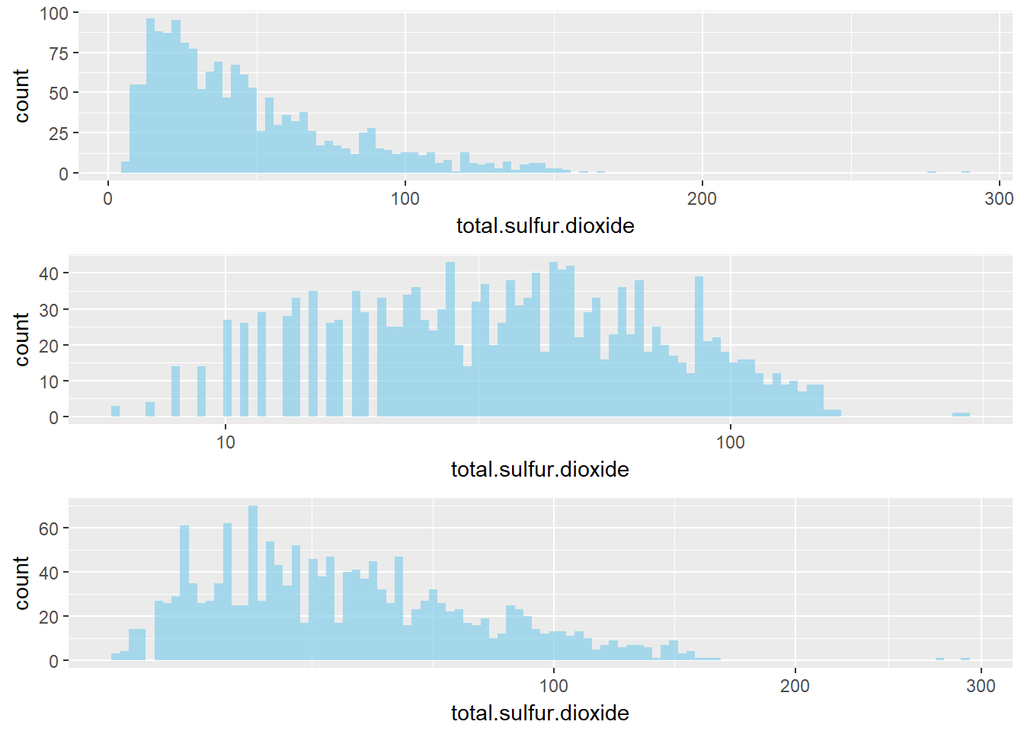

##### Strongly correlated with free sulfur dioxide wich make sense since because is actualy the amount of free sulfur dioxide and bound forms of S02. dispite the correlation with the residual sugar is not too much relevant, would be great to aproach them in a bivariate analysis.

## 1.7 - Free Sulfur Dioxide

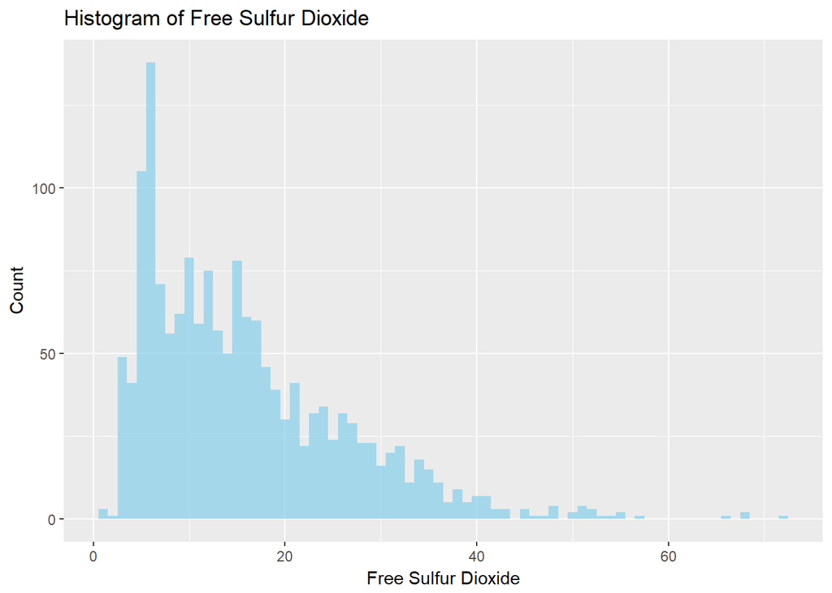

```
##    Min. 1st Qu.  Median    Mean 3rd Qu.    Max.
##    1.00    7.00   14.00   15.87   21.00   72.00
```

```
##
##    1    2    3    4    5  5.5    6    7    8    9   10   11   12   13   14
##    3    1   49   41  104    1  138   71   56   62   79   59   75   57   50
##   15   16   17   18   19   20   21   22   23   24   25   26   27   28   29
##   78   61   60   46   39   30   41   22   32   34   24   32   29   23   23
##   30   31   32   33   34   35   36   37 37.5   38   39   40 40.5   41   42
##   16   20   22   11   18   15   11    3    2    9    5    6    1    7    3
##   43   45   46   47   48   50   51   52   53   54   55   57   66   68   72
##    3    3    1    1    4    2    4    3    1    1    2    1    1    2    1
```

## 1.8 - Chlorides

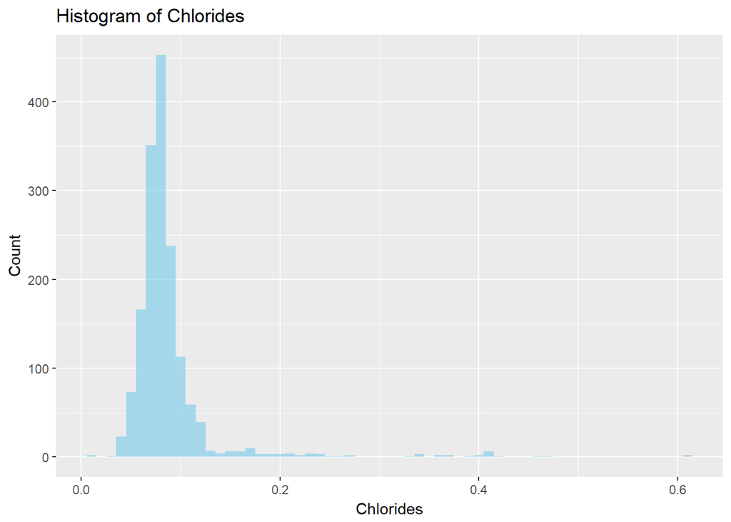

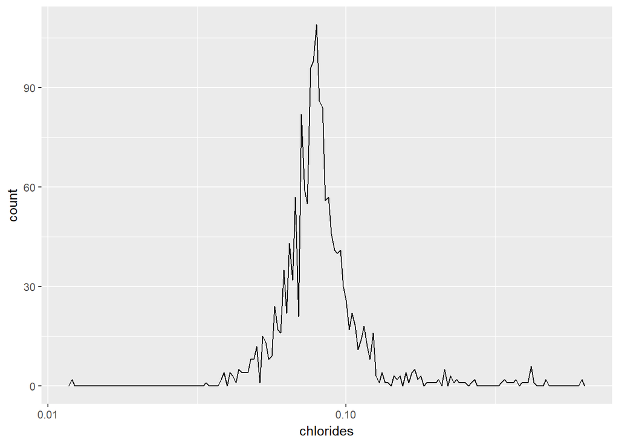

```
##    Min. 1st Qu.  Median    Mean 3rd Qu.    Max.
## 0.01200 0.07000 0.07900 0.08747 0.09000 0.61100
```

##### Is not strongly correlated among the other feauters but decided to see in a log scale due to the fact that was noticed a few apparences of wine with low levels (near zero). which makes interrest to see with more detail.

##### The quantities seems to be constant and low, that can almost be part of a standard and since the correlation with quality is not strong wont be an object of study in a bivariate or multivariate section.

##### The mean and medain are 0.087 and 0.079 respectivectly.

## 1.9 - Residual sugar

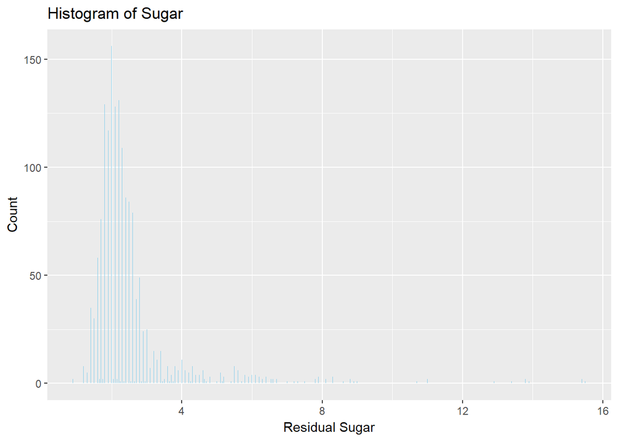

##### We can see in this historam of residual sugar that most of thw wines have low sugar concetration wich can range from 1 to 3 g/L. lets zoom in to see closly how much the diviation can float in this interval.

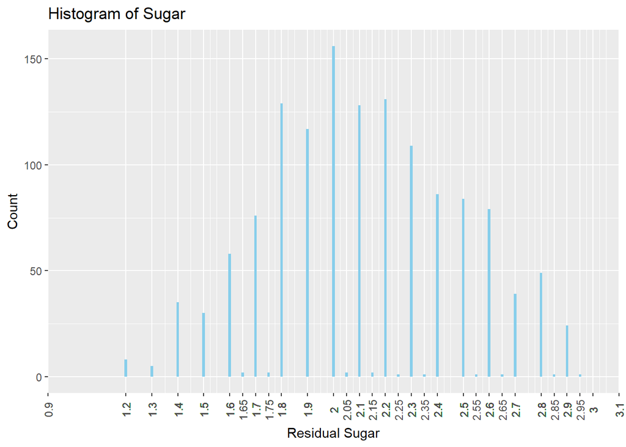

## 1.10 - Citric Acid

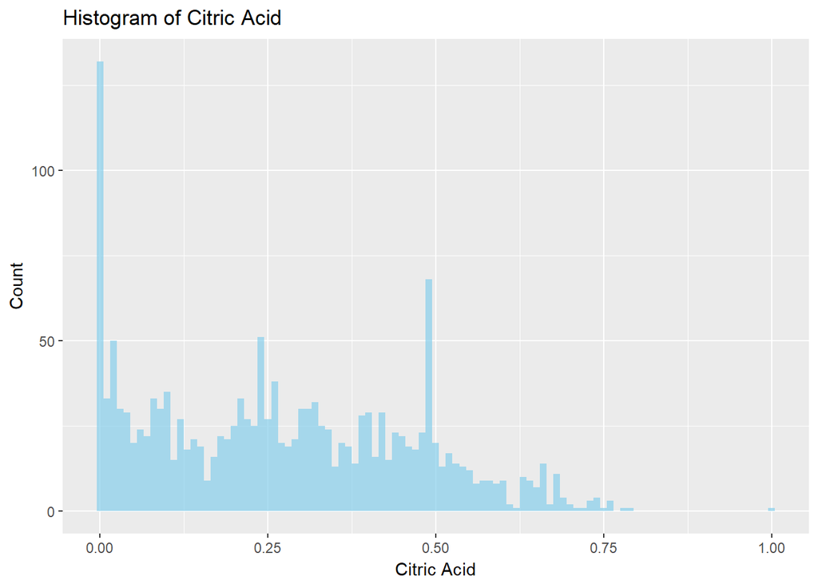

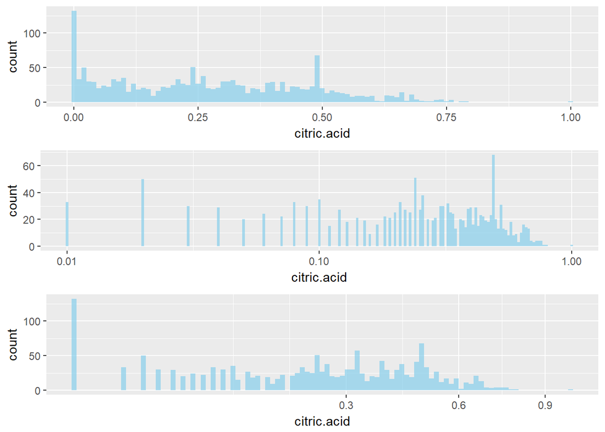

```
##    Min. 1st Qu.  Median    Mean 3rd Qu.    Max.
##   0.000   0.090   0.260   0.271   0.420   1.000
```

```
##
##    0 0.01 0.02 0.03 0.04 0.05 0.06 0.07 0.08 0.09  0.1 0.11 0.12 0.13 0.14
##  132   33   50   30   29   20   24   22   33   30   35   15   27   18   21
## 0.15 0.16 0.17 0.18 0.19  0.2 0.21 0.22 0.23 0.24 0.25 0.26 0.27 0.28 0.29
##   19    9   16   22   21   25   33   27   25   51   27   38   20   19   21
##  0.3 0.31 0.32 0.33 0.34 0.35 0.36 0.37 0.38 0.39  0.4 0.41 0.42 0.43 0.44
##   30   30   32   25   24   13   20   19   14   28   29   16   29   15   23
## 0.45 0.46 0.47 0.48 0.49  0.5 0.51 0.52 0.53 0.54 0.55 0.56 0.57 0.58 0.59
##   22   19   18   23   68   20   13   17   14   13   12    8    9    9    8
##  0.6 0.61 0.62 0.63 0.64 0.65 0.66 0.67 0.68 0.69  0.7 0.71 0.72 0.73 0.74
##    9    2    1   10    9    7   14    2   11    4    2    1    1    3    4
## 0.75 0.76 0.78 0.79    1
##    1    3    1    1    1
```

## 1.11 - Volatile Acidity

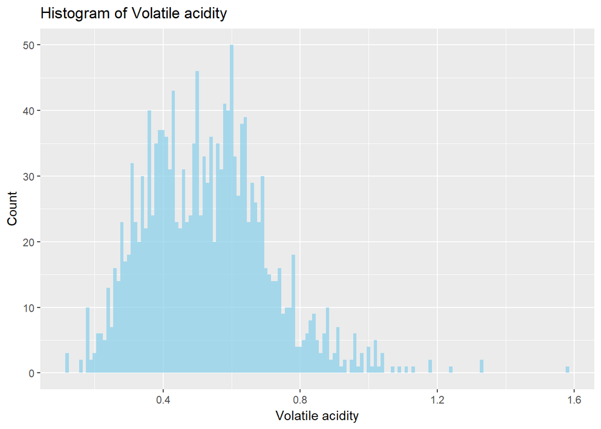

##### Which can be seen as acetic acid in wine, which at too high of levels can lead to an unpleasant, vinegar taste. This is one of the most correlated variables with quality and will be interresting to see in a bivariate analysis.

## 1.12 - Fixed Acidity

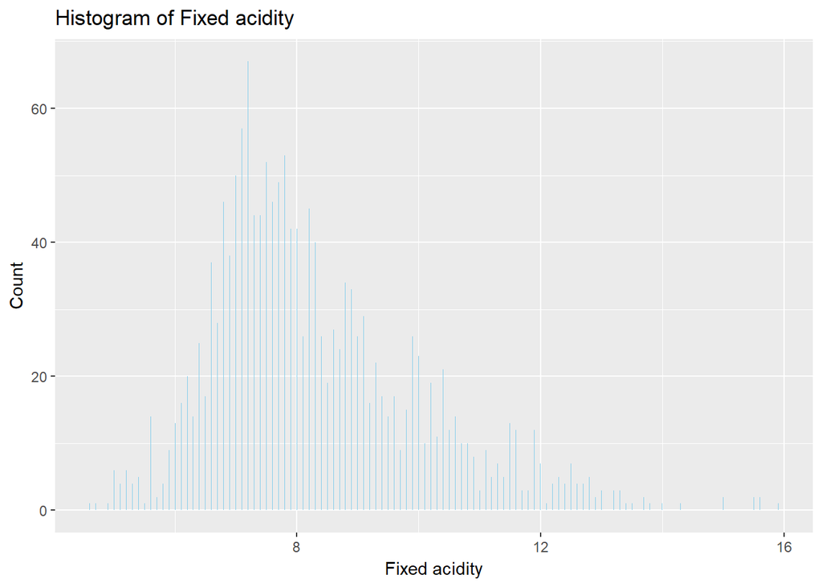

```
## [1] -0.6829782
```

```
## [1] 0.6717034
```

```
## [1] 0.6680473
```

##### High corelated with pH, Citric acid and density. Further plots to better understanding in a bivariate or multivariate anlaysis. Tend to have higher concentration among the acids and that due to the fact that do not evaporate readily.

## 1.13 - pH Levels

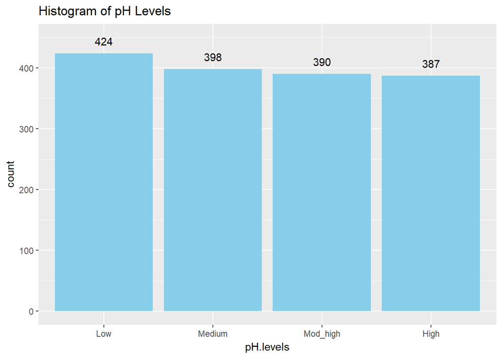

##### The data on pH levels is distribuited almost the same quantity in all 4 categories, Will be used further in Multivariete plots.

## 1.14 - Sugar Levels

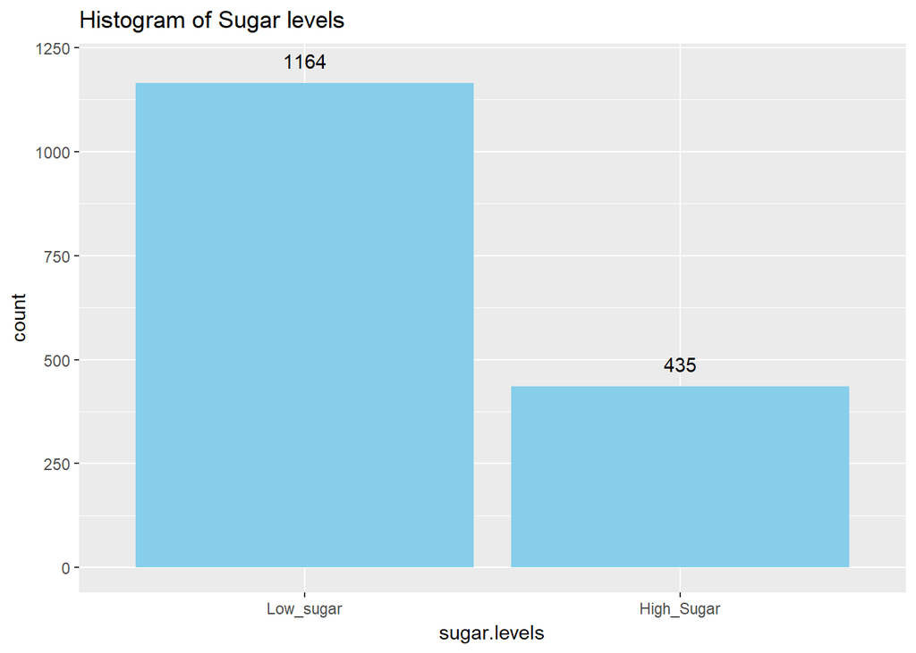

##### Most wines have low sugar, lets see oin future plots ow can influence.

## 1.15 - Alcohol Levels

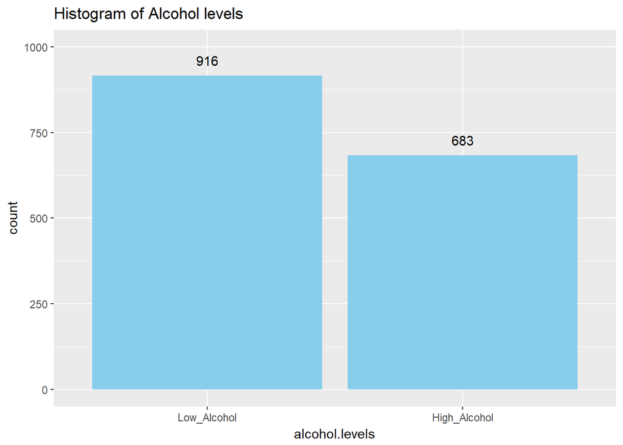

##### Lets go beaneth on alcohol levels to see how they are distributed in quality at multivariate plots.

# Univariate Analysis

##### Besides the structure of the dataset early explained on introduction secction, here is other observations to consider:

##### - Most of the wines are 5 and 6 on the quality scale.

##### - The wines with alcohol of 9.4 and 9.5 are the only ones who have more than 100 wines on the dataset.

##### - knowing that wines with greater than 45 grams/liter are considered sweet. Therefore, the most wines on the dataset have low sugar.

##### The main feature in the dataset is quality, and its strong correlated with alcohol and volatile.acidity. Also found interresting to study density beacuse i could notice that is high correlated with many variables dispite the fact that is not high correlated with quality, that can be tricky but its also make sence if we bear in mind that the water can alter the impact of the residual sugar and alcohol on the wine.

##### Also found important to study fixed.acidity since its the only variable strong correlated with 3 variables (citric.acidity, pH and density) which we will have an oportunity to have a deep analysis on them on bivariate and multivariete.

##### Created 3 factorial variables that i believe that will help to group certian behaviors that can influence to the wine quality. As an example the sugar levels seems to be lower in all wines but would be interresting to see how can be spread in each quality as well in density, in that regards would be a great field to explore.

##### Droped the column X, because contains irrelevant information and have zero impact to the quality.

##### I log-transformed the right skewed chlorides (salt) to better see the distribuiton of the data where the result was a normal distribuited plot, and we can notice a tail on the right. The original plot and residual sugar have the same shape. But the opposite of residual sugar, chlorides is not strongly correlated with density and its safe to say that its because of the low levels of it on entire wine data set.

# Bivariate Plots Section

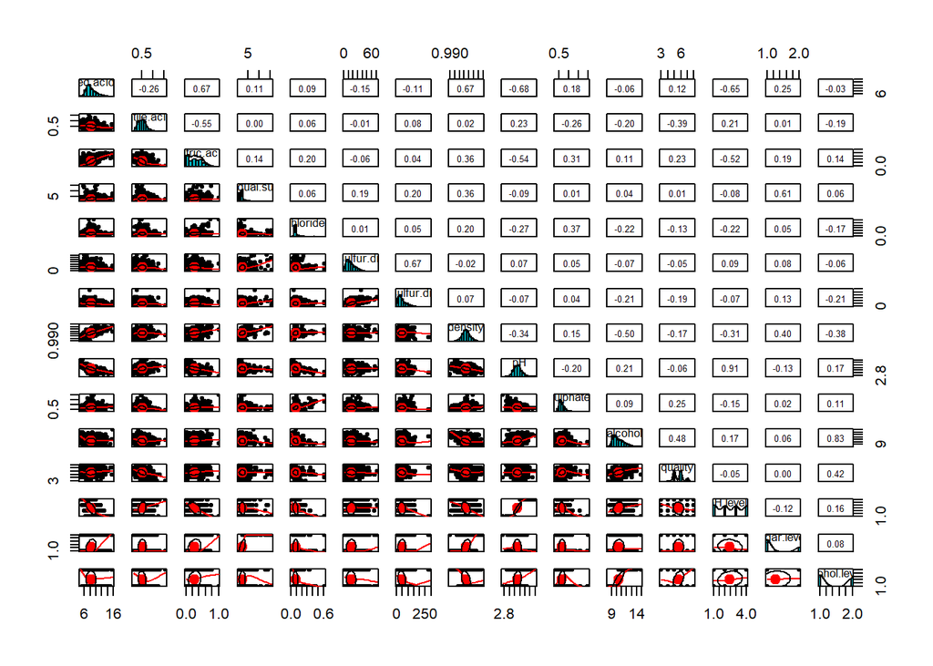

## 2.1 - pH vs Fixed Acidity

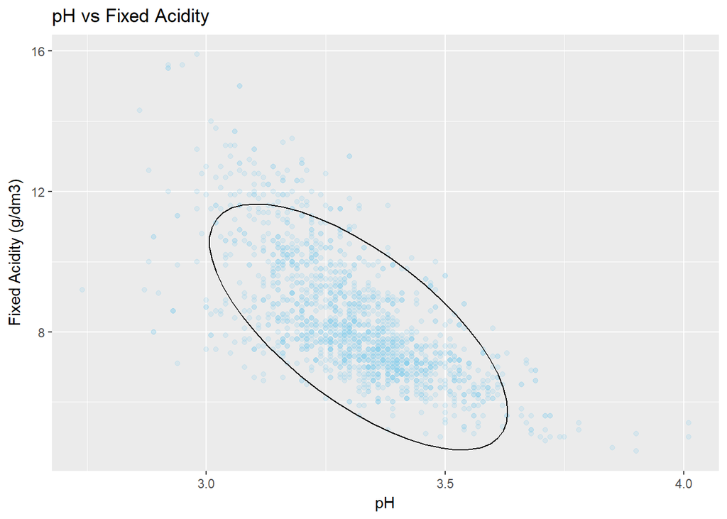

## 2.2 - pH vs Citric Acid

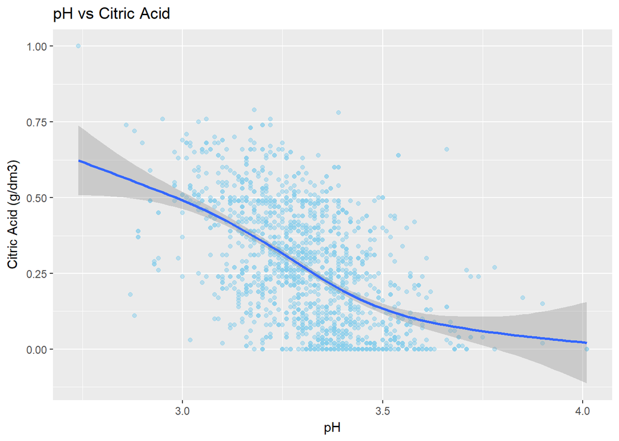

## 2.3 - Fixed Acid vs Density

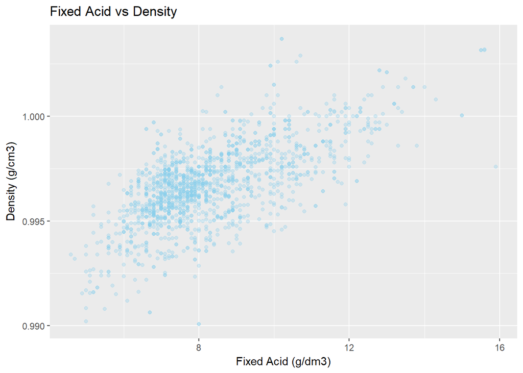

## 2.4 - Citric Acid vs Density

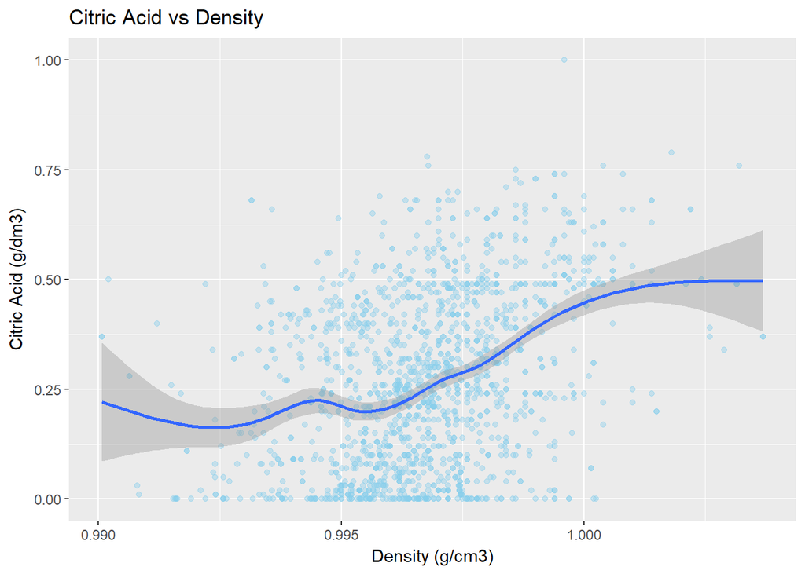

## 2.5 - Sugar vs Density

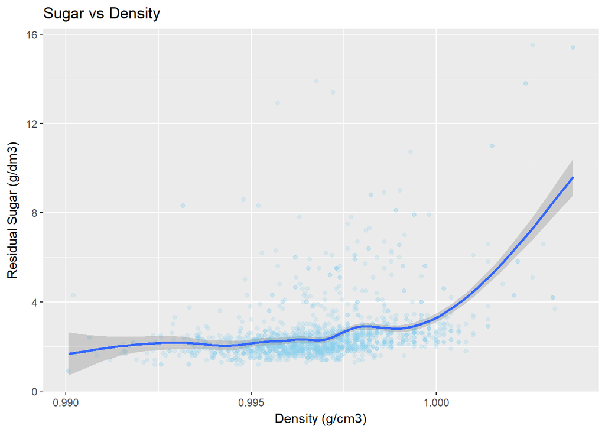

##### The density seems to be distribuited from 0.992 to 1.0 mostly with low sugar despite the fact that from the density greater than 1.0 the sugar levels tends to raise. Wich is not seem to be the behave of wine with quality, that can be concluded from the bellow plot where its possible to see that high density leads to a low rate of alcohol.

## 2.6 - Alcohol vs Density

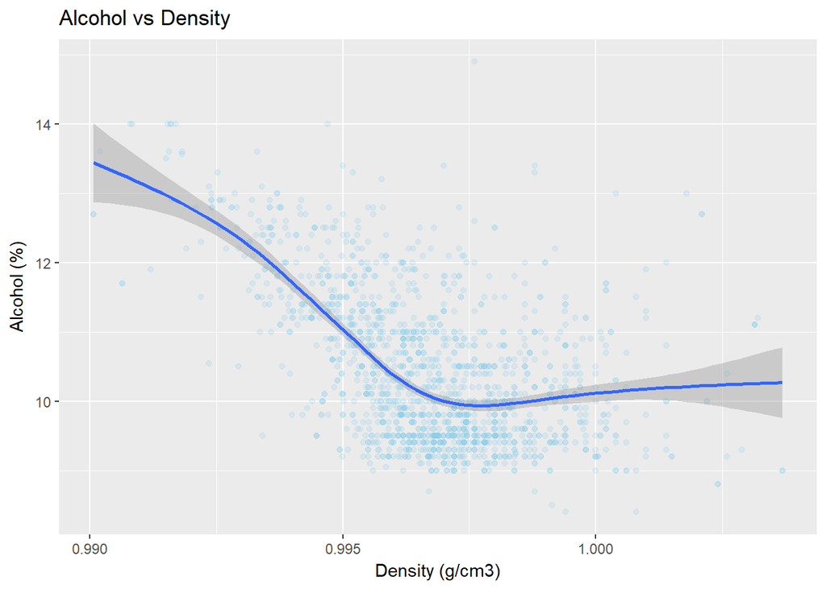

## 2.7 - Alcohol vs Quality

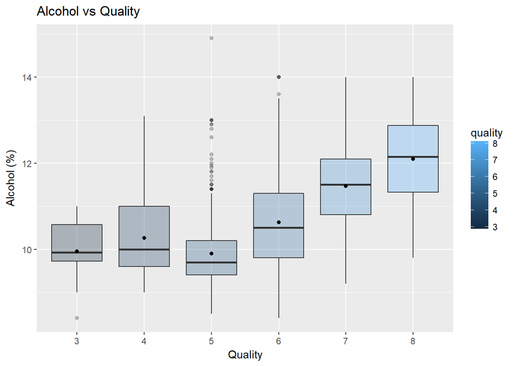

##### As part of the process of fermentation the sugar can be converted to alcohol and since the most of the good wines can take years to ferment the alcohol levels are equally increase making sense to the above plot were we can see the trend on good wines have the high percent of alcohol.

## 2.8 - Volatile Acidity vs Sulphates

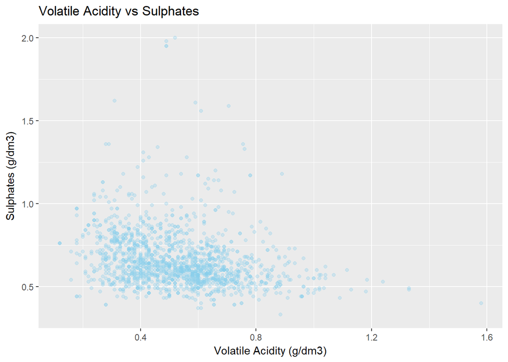

##### Correlation coeficient between (Volatile Acidity & Sulphates)

```
## [1] -0.2609867
```

##### Correlation coeficient between Total and free Sulfur Dioxide

```
## [1] 0.6676665
```

##### Its also important to refer that the high concentration on sulphates can influence the have a low amount of volatile acidity which is great as we can see on the bellow plot.

## 2.9 - Volatile Acidity vs Quality

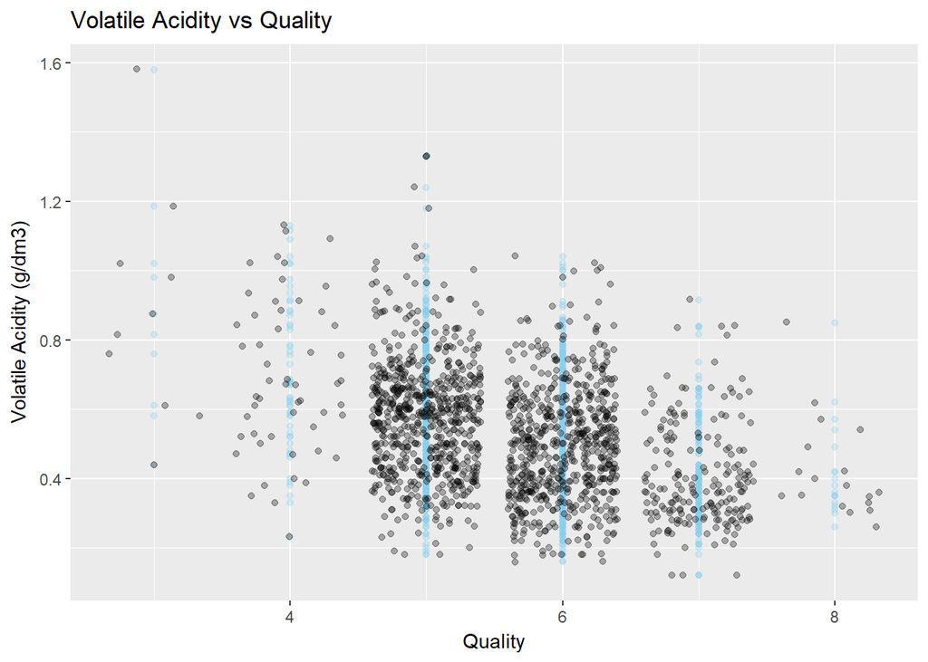

# Bivariate Analysis

##### We found out that ph is invertionaly proportional to citric acidity and fixed acidity wich affects the wine quality on aspects like frashness, flavor and taste of the wine.

##### Tried to check density were i found that have a good correlation with the fixed.acidity and citric acidity both variables can be relevant to the wine quality when they exposed to a high values.

##### The residual sugar has low concentration among the best wines, wich that can be from the fact that the fermentation increases the alcohol percentage. Wich is correlated with the quality of the wine.

##### I could observe interesting relationships and fixed acidity has demonstrated as an important variable despite the fact that have a low correlation with the quality. In that regards, i have also compared to others variables wich can influence the quality wine.

##### Other stronger relationship Was fixed acidity with density and if we cascade we can see that density is also related ti with alcohol wich is related to the wine quality.

# 3 - Multivariate Plots Section

## 3.1 - Alcohol, Sugar & Quality

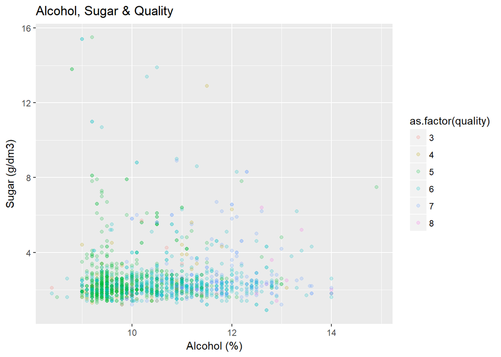

##### In this plot we can see that the green colour (quality = 5) its more present on the left side meaning that level of the alcohol is low. Unfortunatley we cant get an exactly orverview on each quality caterogry. Lets separete the quality to get more visibility and also add the Volatile Acidity since is one of the most correlated qith quality.

## 3.2 - Alcohol, Sugar Levels & Volatile Acidity

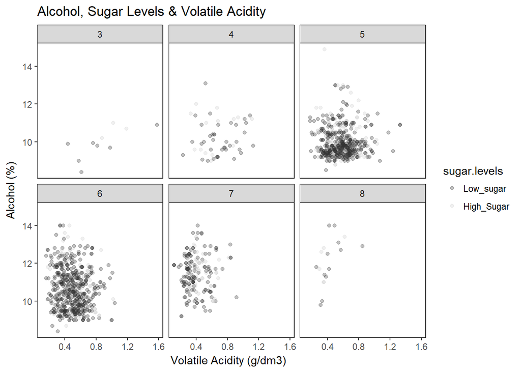

```
##
##                3   4   5   6   7   8
##   Low_sugar    7  38 488 482 137  12
##   High_Sugar   3  15 193 156  62   6
```

##### Giving a first look on quality 4 comparing with 8, we can see that the same portion of low sugar appear in both qualities. Invalidating the possibility of the fermentation be the cause of the reduce of sugar concentration or if its not the case the other variables can also influence to retain more sugar or can be the fact that the data was limited in since we couldnt find any sweet wine to use for comparation. In overall all qualites of wine have mostly low sugar.

##### The Volatile acidity and Alcohol remain the same on the last conclusion were the plots can show cleary that the low level of volatile acidity i more patent on the best quality wine combined by the high rate of alcohol. And the opposite happen as we decrease the quality of the wine.